# Austrálske víno

**Dáta v súbore WINE.dat predstavujú predaj austrálskeho červeného vína za obdobie január 1980 - október 1991 zaznamenávané mesačne**

#### Načítanie dát

```r
WINE <- read.table("WINE.DAT")
str(WINE)
```

```
## 'data.frame':    142 obs. of  1 variable:
##  $ V1: int  464 675 703 887 1139 1077 1318 1260 1120 963 ...
```

Načítanie do premennej “vinodata”

```r
vinodata<-WINE$V1
```

#### Zobrazenie časového radu

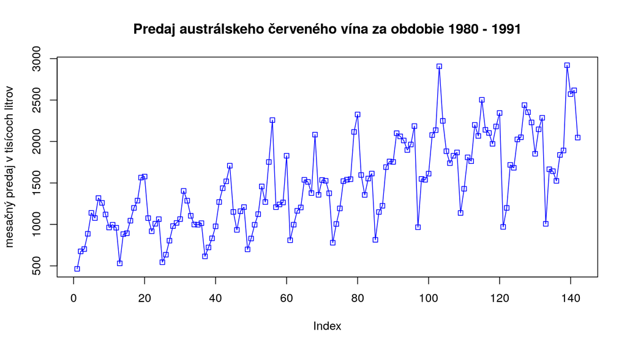

```r
plot(vinodata, type = "o", main = "Predaj austrálskeho červeného vína za obdobie 1980 - 1991", ylab="mesačný predaj v tisícoch litrov", col="blue", pch=22)
```

#### Pozorovanie

- rastúci trend - zrejme lineárny
- rastúca variabilita - log transformácia
- výrazná sezónna zložka

**Úloha: Rastúci trend a sezónnosť vieme naraz odstrániť diferencovaním. Akým?**

- polynomický trend - diferencovanie znižuje rád polynómu o stupeň
- sezónnosť - diferencovanie s oneskorením, ktoré sa rovná perióde
- možno použiť aj kĺzavé priemery - máme síce periódu 12 ale použijeme 13, lebo chceme nepárne

**Úloha: Nájdite model ČR pomocou spektrálnej analýzy.**

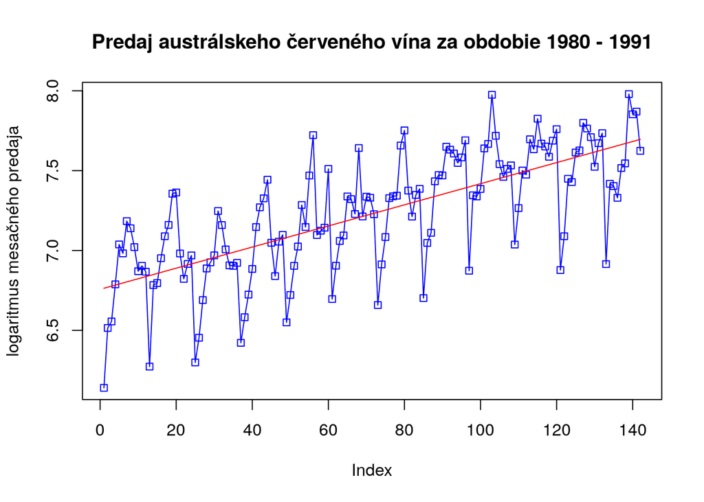

```r
lVino <- log(vinodata)
plot(lVino, type = "o", main = "Predaj austrálskeho červeného vína za obdobie 1980 - 1991", ylab="logaritmus mesačného predaja", col="blue", pch=22)

# Fitujeme priamkou
cas = 1:length(lVino)
lmVino <- lm(lVino~cas)

# Prelozime graf priamkou
lines(cas,predict(lmVino), col='red')
```

Chceme stacionárny rad.

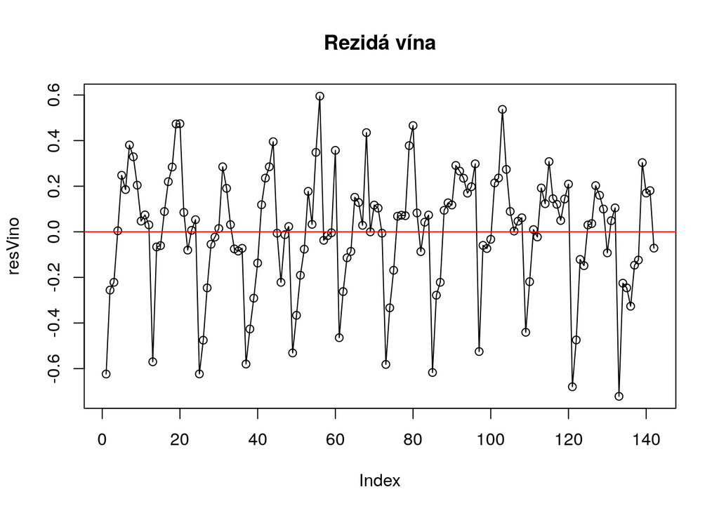

```r
resVino <- residuals(lmVino)
plot(resVino, main='Rezidá vína', type = 'o')
abline(0,0,col = 'red')
```

Vieme, že máme silnú sezónnu zložku. Všetky vety v spektrálnej analýze požadujú stacionárny rad, ktorý sme si práve vyrobili.

```r
vinaPer <- spec.pgram(resVino, log='no')
```

[figure not shown]

```r
vinaPer$freq[12] # bez 2pi
```

```
## [1] 0.08333333
```

Hodnota významnej frekvencie je 0.08333, čo je presne 1/12. Takže teraz vyskúšame model s frekvenciou 12.

#### Nájdime model s jednou významnou frekvenciou:

```r
c <- cos(2*pi*1/12*cas)
s <- sin(2*pi*1/12*cas)

periodaTrend <- lm(lVino~cas+c+s)
periodaTrend
```

```
##
## Call:
## lm(formula = lVino ~ cas + c + s)
##
## Coefficients:
## (Intercept)          cas            c            s
##    6.773046     0.006361    -0.194567    -0.204335
```

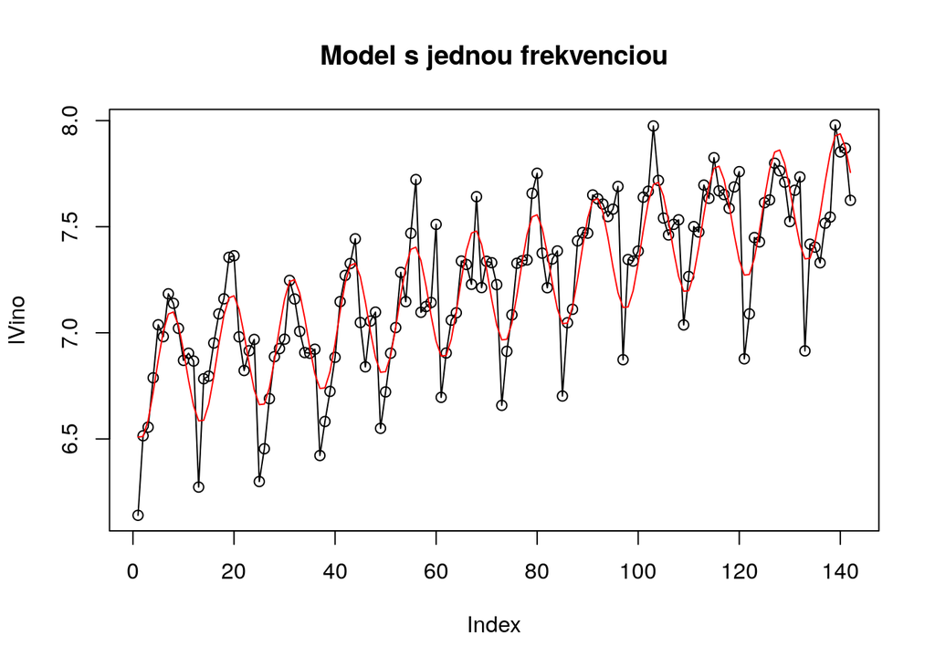

```r
plot(lVino, main = 'Model s jednou frekvenciou', type = 'o')
lines(cas, predict(periodaTrend), col='red')
```

#### Analýza reziduí

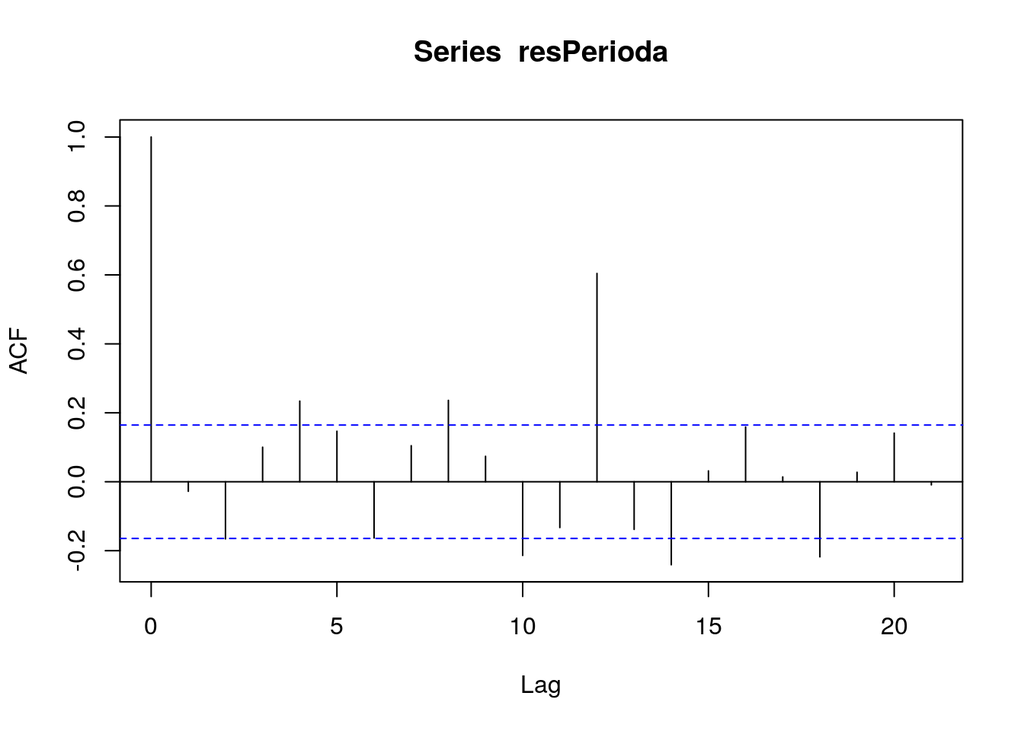

```r
resPerioda <- residuals(periodaTrend)
acfPer <- acf(resPerioda)
```

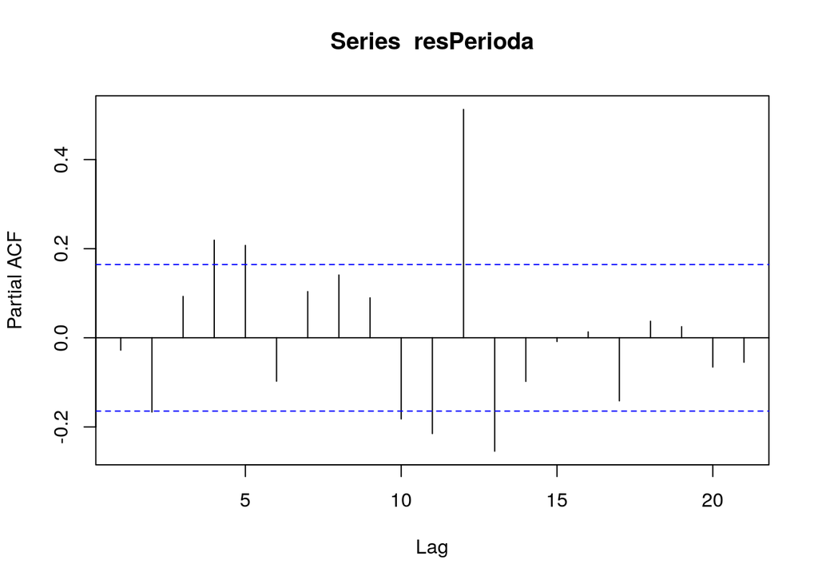

```r
pacfPef <- pacf(resPerioda)
```

Nestačí nám zobrať len jednu významnú frekvenciu, stále je tam nejaká periodicita.

#### Vylepšený model s 2 významnými frekvenciami

```r
c <- cos(2*pi*1/12*cas)
s <- sin(2*pi*1/12*cas)
c2 <- cos(2*pi*1/4*cas)
s2 <- sin(2*pi*1/4*cas)

periodaTrend2 <- lm(lVino~cas+c+s+c2+s2)
periodaTrend2
```

```
##
## Call:
## lm(formula = lVino ~ cas + c + s + c2 + s2)
##
## Coefficients:
## (Intercept)          cas            c            s           c2
##    6.774417     0.006361    -0.192017    -0.205033     0.092557
##          s2
##   -0.096691
```

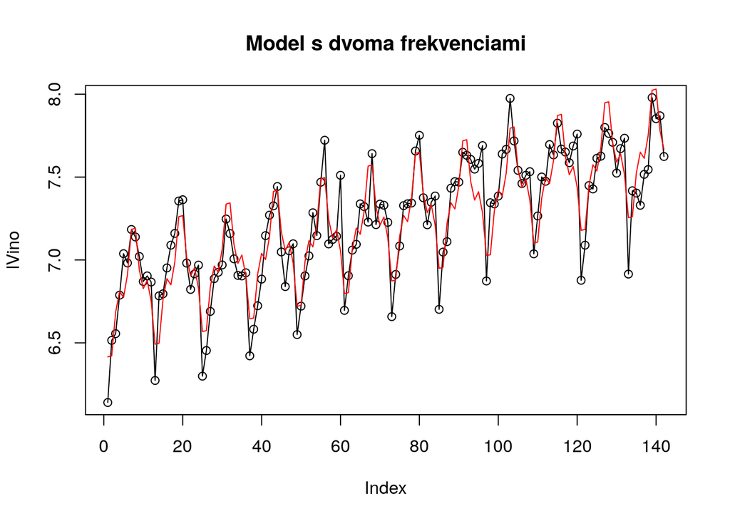

```r
plot(lVino, main = 'Model s dvoma frekvenciami', type = 'o')
lines(cas, predict(periodaTrend2), col='red')
```

Tento model odhaduje dáta ešte lepšie :D

#### Analýza reziduí, ktoré získame vylepšeným modelom:

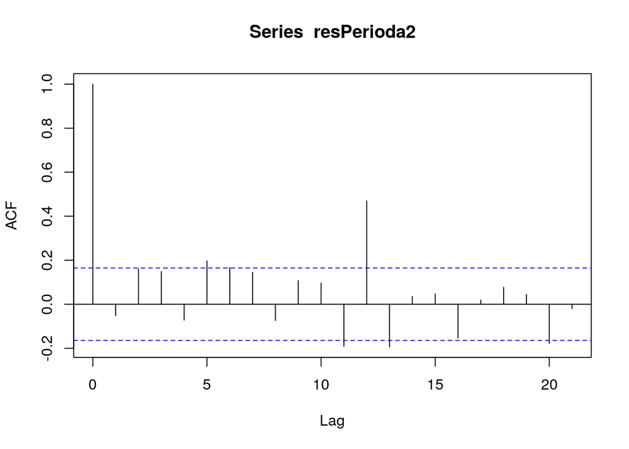

```r
resPerioda2 <- residuals(periodaTrend2)
acfPer2 <- acf(resPerioda2)
```

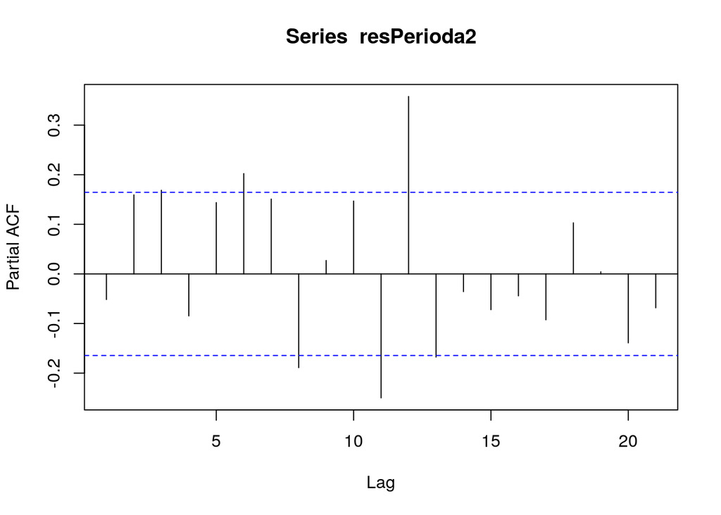

```r
pacfPef2 <- pacf(resPerioda2)
```

```r
Box.test(resPerioda2)
```

```
##
##  Box-Pierce test
##
## data:  resPerioda2
## X-squared = 0.37822, df = 1, p-value = 0.5386
```

```r
Box.test(resPerioda2,type='Ljung')
```

```
##
##  Box-Ljung test
##
## data:  resPerioda2
## X-squared = 0.38627, df = 1, p-value = 0.5343
```

Box však hypotézu neodmieta. Ďalšie spresňovanie by znamenalo, že musíme odhadovať ďalšie dva parametre, takže sa uspokojíme s tým, čo už máme.

#### Ako vyzerá kompletný model?

```r
summary(periodaTrend2)
```

```
##
## Call:
## lm(formula = lVino ~ cas + c + s + c2 + s2)
##
## Residuals:
##      Min       1Q   Median       3Q      Max
## -0.34016 -0.09475 -0.00604  0.09536  0.45438
##
## Coefficients:
##               Estimate Std. Error t value Pr(>|t|)
## (Intercept)  6.7744165  0.0256870 263.729  < 2e-16 ***
## cas          0.0063607  0.0003118  20.401  < 2e-16 ***
## c           -0.1920171  0.0181481 -10.581  < 2e-16 ***
## s           -0.2050335  0.0179781 -11.405  < 2e-16 ***
## c2           0.0925571  0.0180460   5.129 9.83e-07 ***
## s2          -0.0966911  0.0180460  -5.358 3.50e-07 ***
## ---
## Signif. codes:  0 '***' 0.001 '**' 0.01 '*' 0.05 '.' 0.1 ' ' 1
##
## Residual standard error: 0.152 on 136 degrees of freedom
## Multiple R-squared:  0.8468, Adjusted R-squared:  0.8412
## F-statistic: 150.3 on 5 and 136 DF,  p-value: < 2.2e-16
```

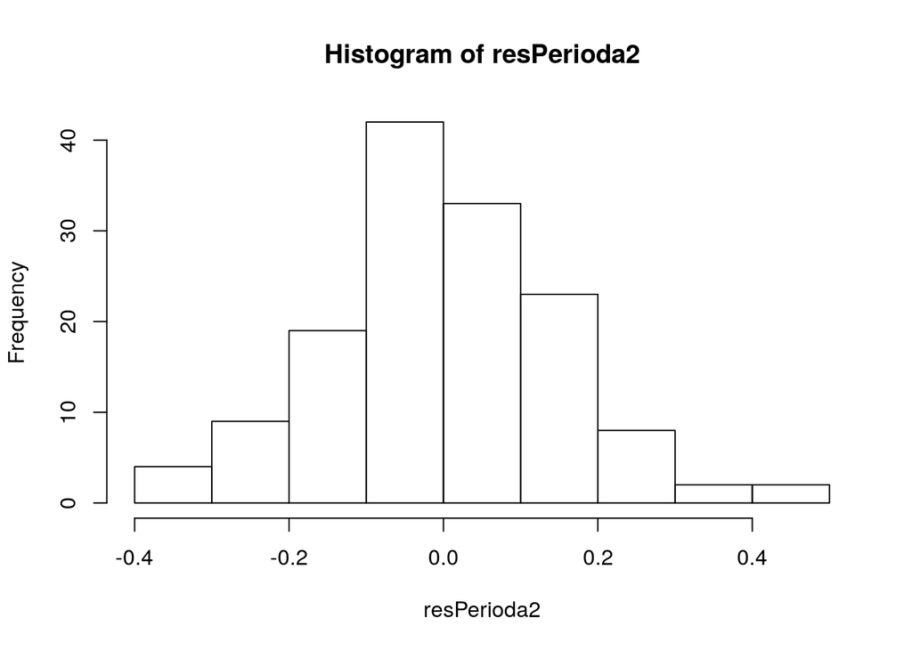

```r
hist(resPerioda2)
```

```r
shapiro.test(resPerioda2)
```

```
##
##  Shapiro-Wilk normality test
##
## data:  resPerioda2
## W = 0.99394, p-value = 0.8152
```